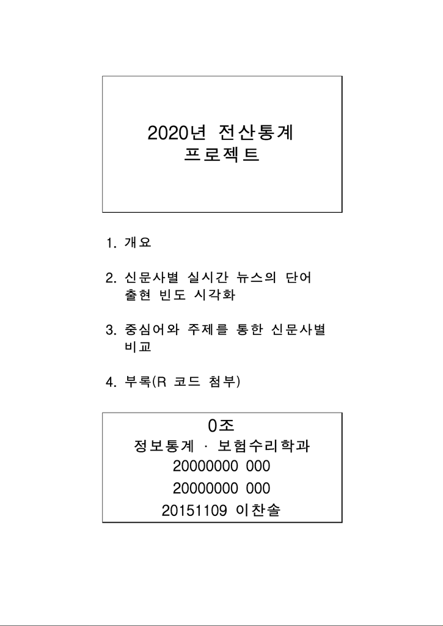

2020년 전산통계

프로젝트

1. 개요

2. 신문사별 실시간 뉴스의 단어

출현 빈도 시각화

3. 중심어와 주제를 통한 신문사별

비교

4. 부록(R 코드 첨부)

0조

정보통계 · 보험수리학과

20000000 000

20000000 000

20151109 이찬솔

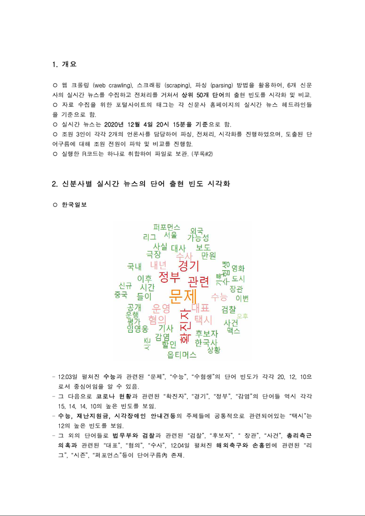

1. 개요

○

웹 크롤링 (web crawling), 스크래핑 (scraping), 파싱 (parsing) 방법을 활용하여, 6개 신문

사의 실시간 뉴스를 수집하고 전처리를 거쳐서

상위 50개 단어

의 출현 빈도를 시각화 및 비교.

○

자료 수집을 위한 포털사이트의 태그는 각 신문사 홈페이지의 실시간 뉴스 헤드라인들

을 기준으로 함.

○

실시간 뉴스는

2020년 12월 4일 20시 15분을 기준

으로 함.

○

조원 3인이 각각 2개의 언론사를 담당하여 파싱, 전처리, 시각화를 진행하였으며, 도출된 단

어구름에 대해 조원 전원이 파악 및 비교를 진행함.

○

실행한 R코드는 하나로 취합하여 파일로 보관. (부록#2)

2. 신분사별 실시간 뉴스의 단어 출현 빈도 시각화

○

한국일보

- 12.03일 펼쳐진

수능

과 관련된 “문제”, “수능”, “수험생”의 단어 빈도가 각각 20, 12, 10으

로서 중심어임을 알 수 있음.

- 그 다음으로

코로나 현황

과 관련된 “확진자”, “경기”, “정부”, “감염”의 단어들 역시 각각

15, 14, 14, 10의 높은 빈도를 보임.

-

수능, 재난지원금, 시각장애인 안내견등

의 주제들에 공통적으로 관련되어있는 “택시”는

12의 높은 빈도를 보임.

- 그 외의 단어들로

법무부와 검찰

과 관련된 “검찰”, “후보자”, “ 장관”, “사건”,

총리측근

의혹과

관련된 “대표”, “혐의”, “수사”, 12.04일 펼쳐진

해외축구와 손흥민

에 관련된 “리

그”, “시즌”, “퍼포먼스”등이 단어구름內 존재.

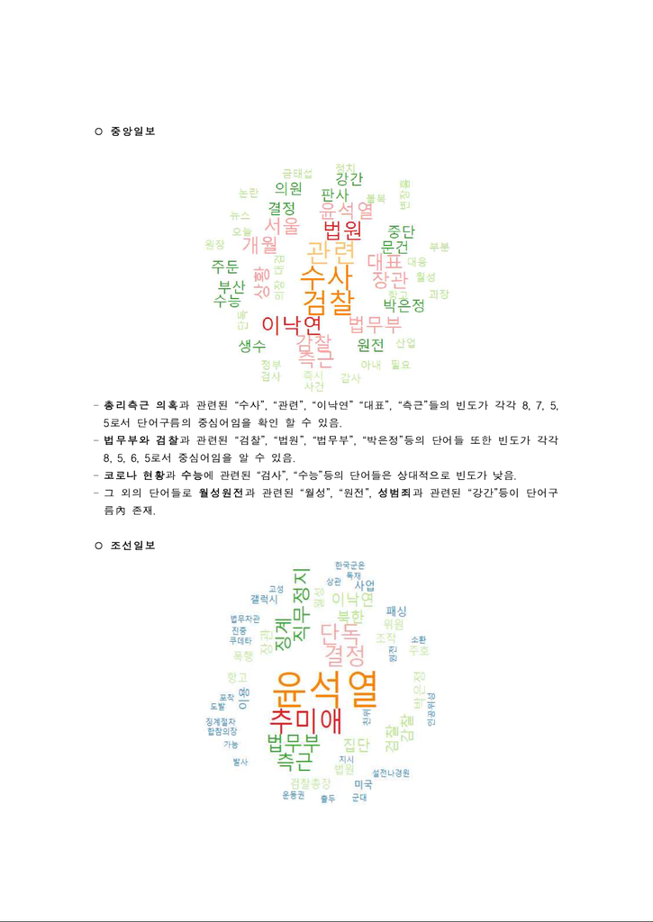

○

중앙일보

-

총리측근 의혹

과 관련된 “수사”, “관련”, “이낙연” “대표”, “측근”들의 빈도가 각각 8, 7, 5,

5로서 단어구름의 중심어임을 확인 할 수 있음.

-

법무부와 검찰

과 관련된 “검찰”, “법원”, “법무부”, “박은정”등의 단어들 또한 빈도가 각각

8, 5, 6, 5로서 중심어임을 알 수 있음.

-

코로나 현황

과

수능

에 관련된 “검사”, “수능”등의 단어들은 상대적으로 빈도가 낮음.

- 그 외의 단어들로

월성원전

과 관련된 “월성”, “원전”,

성범죄

과 관련된 “강간”등이 단어구

름內 존재.

○

조선일보

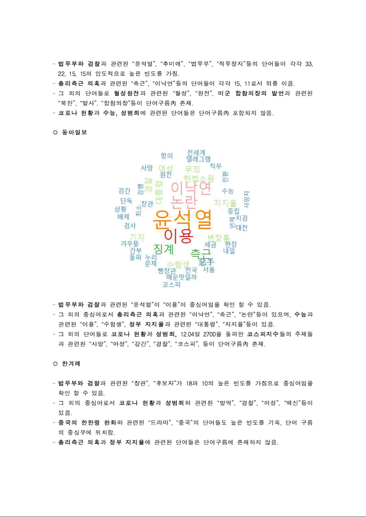

-

법무부와 검찰

과 관련된 “윤석열”, “추미애”, “법무부”, “직무정지”등의 단어들이 각각 33,

22, 15, 15의 압도적으로 높은 빈도를 가짐.

-

총리측근 의혹

과 관련된 “측근”, “이낙연”등의 단어들이 각각 15, 11로서 뒤를 이음.

- 그 외의 단어들로

월성원전

과 관련된 “월성”, “원전”,

미군 합참의장의 발언

과 관련된

“북한”, “발사”. “합참의장”등이 단어구름內 존재.

-

코로나 현황

과

수능, 성범죄

에 관련된 단어들은 단어구름內 포함되지 않음.

○

동아일보

-

법무부와 검찰

과 관련된 “윤석열”이 “이용”이 중심어임을 확인 할 수 있음.

- 그 외의 중심어로서

총리측근 의혹

과 관련된 “이낙연”, “측근”, “논란”등이 있으며,

수능

과

관련된 “이용”, “수험생”,

정부 지지율

과 관련된 “대통령”, “지지율”등이 있음.

- 그 외의 단어들로

코로나 현황

과

성범죄,

12.04일 2700을 돌파한

코스피지수

들의 주제들

과 관련된 “사망”, “여성”, “강간”, “경찰”, “코스피”, 등이 단어구름內 존재.

○

한겨례

-

법무부와 검찰

과 관련된 “장관”, “후보자”가 18과 10의 높은 빈도를 가짐으로 중심어임을

확인 할 수 있음.

- 그 외의 중심어로서

코로나 현황

과

성범죄

와 관련된 “방역”, “경찰”, “여성”, “백신”등이

있음.

-

중국의 한한령 완화

와 관련된 “드라마”, “중국”의 단어들도 높은 빈도를 기록, 단어 구름

의 중심부에 위치함.

-

총리측근 의혹

과

정부 지지율

에 관련된 단어들은 단어구름에 존재하지 않음.

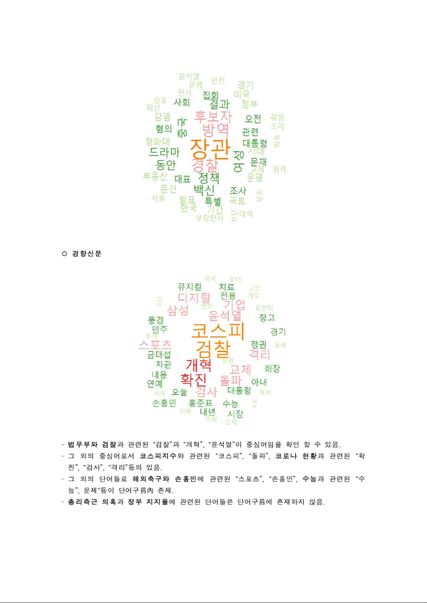

○

경향신문

-

법무부와 검찰

과 관련된 “검찰”과 “개혁”, “윤석열”이 중심어임을 확인 할 수 있음.

- 그 외의 중심어로서

코스피지수

와 관련된 “코스피”, “돌파”,

코로나 현황

과 관련된 “확

진”, “검사”, “격리”등의 있음.

- 그 외의 단어들로

해외축구와 손흥민

에 관련된 “스포츠”, “손흥민”,

수능

과 관련된 “수

능”, 문제“등이 단어구름內 존재.

-

총리측근 의혹

과

정부 지지율

에 관련된 단어들은 단어구름에 존재하지 않음.

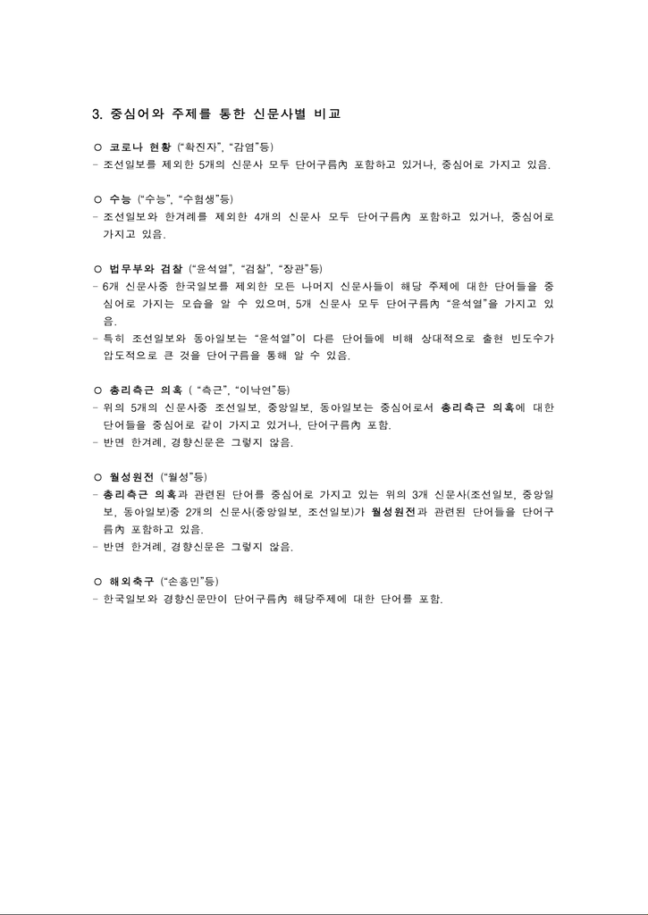

3. 중심어와 주제를 통한 신문사별 비교

○

코로나 현황

(“확진자”, “감염”등)

- 조선일보를 제외한 5개의 신문사 모두 단어구름內 포함하고 있거나, 중심어로 가지고 있음.

○

수능

(“수능”, “수험생”등)

- 조선일보와 한겨례를 제외한 4개의 신문사 모두 단어구름內 포함하고 있거나, 중심어로

가지고 있음.

○

법무부와 검찰

(“윤석열”, “검찰”, “장관”등)

- 6개 신문사중 한국일보를 제외한 모든 나머지 신문사들이 해당 주제에 대한 단어들을 중

심어로 가지는 모습을 알 수 있으며, 5개 신문사 모두 단어구름內 “윤석열”을 가지고 있

음.

- 특히 조선일보와 동아일보는 “윤석열”이 다른 단어들에 비해 상대적으로 출현 빈도수가

압도적으로 큰 것을 단어구름을 통해 알 수 있음.

○

총리측근 의혹

( “측근”, “이낙연”등)

- 위의 5개의 신문사중 조선일보, 중앙일보, 동아일보는 중심어로서

총리측근 의혹

에 대한

단어들을 중심어로 같이 가지고 있거나, 단어구름內 포함.

- 반면 한겨례, 경향신문은 그렇지 않음.

○

월성원전

(“월성”등)

-

총리측근 의혹

월성원전

과 관련된 단어들을 단어구

름內 포함하고 있음.

- 반면 한겨례, 경향신문은 그렇지 않음.

○

해외축구

(“손흥민”등)

- 한국일보와 경향신문만이 단어구름內 해당주제에 대한 단어를 포함.

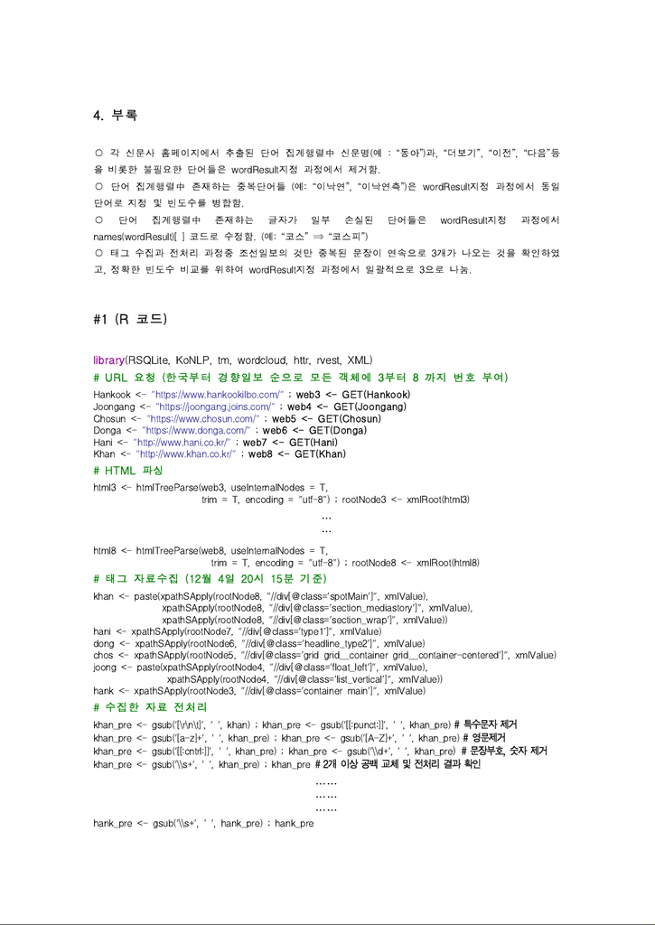

4. 부록

○

각 신문사 홈페이지에서 추출된 단어 집계행렬中 신문명(예 : “동아”)과, “더보기”, “이전”, “다음”등

을 비롯한 불필요한 단어들은 wordResult지정 과정에서 제거함.

○

단어 집계행렬中 존재하는 중복단어들 (예: “이낙연”, “이낙연측”)은 wordResult지정 과정에서 동일

단어로 지정 및 빈도수를 병합함.

○

단어 집계행렬中 존재하는 글자가 일부 손실된 단어들은 wordResult지정 과정에서

[ ]

코드로 수정함. (예: “코스”

⇒

“코스피”)

○

태그 수집과 전처리 과정중 조선일보의 것만 중복된 문장이 연

속

으로 3개가 나

오

는 것을 확인하였

고, 정확한 빈도수 비교를 위하여 wordResult지정 과정에서 일

괄

적으로 3으로 나

눔

.

#1 (R 코드)

library

(R

SQL

ite,

K

o

NLP

, t

m

, wordcloud,

h

ttr, r

v

est,

XML

)

# URL 요청 (한국부터 경향일보 순으로 모든 객체에 3부터 8 까지 번호 부여)

-

"h

ttps:

//

www.

h

an

k

oo

k

ilbo.co

m/" ;

web3 <- GET(Hankook)

J

oongang

<

-

"h

ttps:

//j

oongang.

j

oins.co

m/" ;

web4 <- GET(Joongang)

Ch

osun

<

-

"h

ttps:

//

www.c

h

osun.co

m/" ;

web5 <- GET(Chosun)

D

onga

<

-

"h

ttps:

//

www.donga.co

m/" ;

web6 <- GET(Donga)

H

ani

<

-

"h

ttp:

//

www.

h

ani.co.

k

r

/" ;

web7 <- GET(Hani)

Kh

an

<

-

"h

ttp:

//

www.

kh

an.co.

k

r

/" ;

web8 <- GET(Khan)

# HTML 파싱

<

-

h

t

m

l

T

ree

P

arse(web3, use

I

nternal

N

odes

= T

,

tri

m = T

, encoding

= "

ut

f

-8

"

)

;

root

N

ode3

<

-

xm

lRoot(

h

t

m

l3)

…

…

h

t

m

l8

<

-

h

t

m

l

T

ree

P

arse(web8, use

I

nternal

N

odes

= T

,

tri

m = T

, encoding

= "

ut

f

-8

"

)

;

root

N

ode8

<

-

xm

lRoot(

h

t

m

l8)

# 태그 자료수집 (12월 4일 20시 15분 기준)

kh

an

<

- paste(

pat

hSA

ppl

y

(root

N

ode8,

"//

di

v[@

class

='

spot

M

ain

']"

,

xm

l

V

alue),

x

pat

hSA

ppl

y

(root

N

ode8,

"//

di

v[@

class

='

section

_m

ediastor

y']"

,

xm

l

V

alue),

x

pat

hSA

ppl

y

(root

N

ode8,

"//

di

v[@

class

='

section

_

wrap

']"

,

xm

l

V

alue))

h

ani

<

-

x

pat

hSA

ppl

y

(root

N

ode7,

"//

di

v[@

class

='

t

y

pe1

']"

,

xm

l

V

alue)

dong

<

-

x

pat

hSA

ppl

y

(root

N

ode6,

"//

di

v[@

class

='h

eadline

_

t

y

pe2

']"

,

xm

l

V

alue)

c

h

os

<

-

x

pat

hSA

ppl

y

(root

N

ode5,

"//

di

v[@

class

='

grid grid

__

container grid

__

container-centered

']"

,

xm

l

V

alue)

j

oong

<

- paste(

x

pat

hSA

ppl

y

(root

N

ode4,

"//

di

v[@

class

='f

loat

_

le

f

t

']"

,

xm

l

V

alue),

x

pat

hSA

ppl

y

(root

N

ode4,

"//

di

v[@

class

='

list

_v

ertical

']"

,

xm

l

V

alue))

h

an

k <

-

x

pat

hSA

ppl

y

(root

N

ode3,

"//

di

v[@

class

='

container

m

ain

']"

,

xm

l

V

alue)

# 수집한 자료 전처리

kh

an

_

pre

<

- gsub(

'[\

r

\

n

\

t

]'

,

' '

,

kh

an)

; kh

an

_

pre

<

- gsub(

'[[

:punct:

]]'

,

' '

,

kh

an

_

pre)

# 특수문자 제거

kh

an

_

pre

<

- gsub(

'[

a-

z]+'

,

' '

,

kh

an

_

pre)

; kh

an

_

pre

<

- gsub(

'[A

-

Z]+'

,

' '

,

kh

an

_

pre)

# 영문제거

kh

an

_

pre

<

- gsub(

'[[

:cntrl:

]]'

,

' '

,

kh

an

_

pre)

; kh

an

_

pre

<

- gsub(

'\\

d

+'

,

' '

,

kh

an

_

pre)

# 문장부호 , 숫자 제거

kh

an

_

pre

<

- gsub(

'\\

s

+'

,

' '

,

kh

an

_

pre)

; kh

an

_

pre

# 2개 이상 공백 교체 및 전처리 결과 확인

……

……

……

h

an

k_

pre

<

- gsub(

'\\

s

+'

,

' '

,

h

an

k_

pre)

; h

an

k_

pre

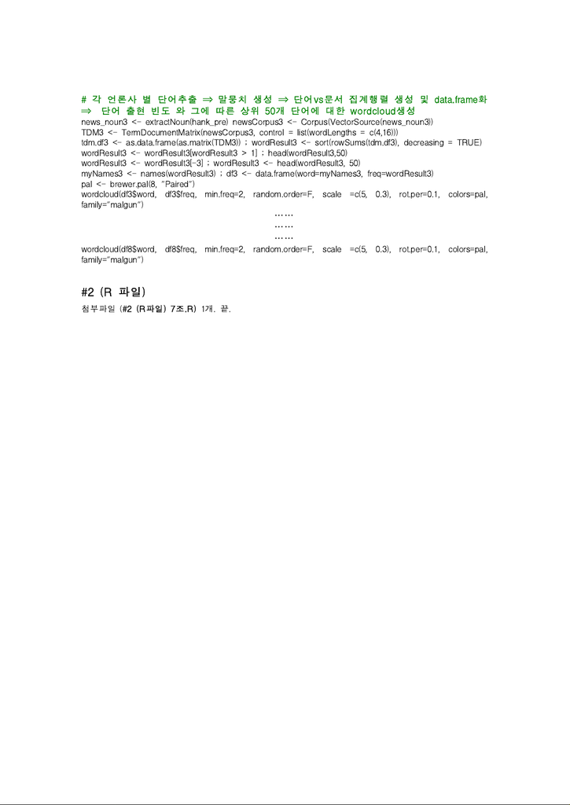

# 각 언론사 별 단어추출

⇒

말뭉치 생성

⇒

단어vs문서 집계행렬 생성 및

data.frame 화

⇒

단어 출현 빈도 와 그에 따른 상위 50개 단어에 대한 wordcloud생성

news

_

noun3

<

N

oun(

h

an

k_

pre) news

C

orpus3

<

-

C

orpus(

V

ector

S

ource(news

_

noun3))

TDM

3

<

-

T

er

mD

ocu

m

ent

M

atri

x

(news

C

orpus3, control

=

list(word

L

engt

h

s

=

c(4,16)))

td

m

.d

f

3

<

- as.data.

f

ra

m

e(as.

m

atri

x

(

TDM

3))

;

wordResult3

<

- sort(row

S

u

m

s(td

m

.d

f

3), decreasing

= T

R

UE

)

wordResult3

<

- wordResult3

[

wordResult3

>

1

] ; h

ead(wordResult3,50)

wordResult3

<

- wordResult3

[

-3

] ;

wordResult3

<

-

h

ead(wordResult3, 50)

myN

a

m

es3

<

- na

m

es(wordResult3)

;

d

f

3

<

- data.

f

ra

m

e(word

=myN

a

m

es3,

f

re

q=

wordResult3)

pal

<

- brewer.pal(8,

"P

aired

"

)

wordcloud(d

f

3

$

word, d

f

3

$f

re

q

,

m

in.

f

re

q=

2, rando

m

.order

=F

, scale

=

c(5, 0.3), rot.per

=

0.1, colors

=

pal,

f

a

m

il

y="m

algun

"

)

……

……

……

wordcloud(d

f

8

$

word, d

f

8

$f

re

q

,

m

in.

f

re

q=

2, rando

m

.order

=F

, scale

=

c(5, 0.3), rot.per

=

0.1, colors

=

pal,

f

a

m

il

y="m

algun

"

)

#2 (R 파일)

첨

부파일 (

#2 (R파일) 7조.R)

1개.

끝

.